# Appendix 2. Data simulation for central place foragers (CPF)

Modelling wildlife habitat selection from tracking data: A practical guide for ecologists

# Workspace setup

```r
library(CircStats)
```

```r
library(terra)
```

```r
library(sf)
```

```r
library(ggplot2)
```

```r
library(doParallel)
```

```r
library(foreach)

set.seed(1234)
```

# Habitat simulation

The simulation domain was defined as a 2,500 km$^2$ area (50 $\times$ 50 km), discretised into a regular grid with a spatial resolution of 100 m. Habitat suitability was represented as a binary chequerboard pattern consisting of alternating 2.5 $\times$ 2.5 km cells, classified as suitable (value = 1) and unsuitable (value = 0).

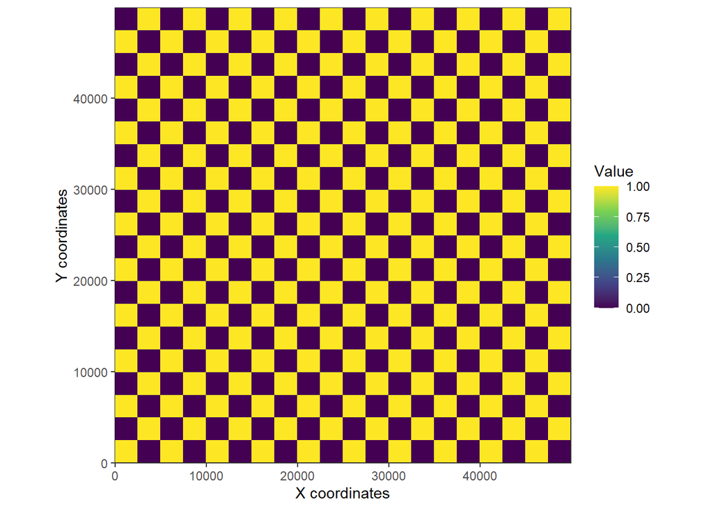

```r
# Define grid in meters: 100 m resolution over 50 km
x_grid <- seq(0, by = 100, length.out = 500)
y_grid <- seq(0, by = 100, length.out = 500)

# Create coordinate grid
coord_df <- expand.grid(x = x_grid, y = y_grid)

# Checkerboard pattern with 2.5 km squares
x_band <- floor(coord_df$x / 2500) %% 2
y_band <- floor(coord_df$y / 2500) %% 2

df <- data.frame(
  x = coord_df$x,
  y = coord_df$y,
  value = as.numeric(x_band == y_band)
)

df$value <- (df$value - min(df$value)) /
  (max(df$value) - min(df$value))

# terra raster
cov_raster <- rast(
  df,
  type = "xyz",
  crs = "EPSG:32630"
)

writeRaster(cov_raster, "cov_raster.tif", overwrite = TRUE)

ggplot(df, aes(x = x, y = y, fill = value)) +
  geom_tile() +
  labs(fill = "Value") +
  xlab("X coordinates")+
  ylab("Y coordinates") +
  scale_fill_viridis_c()+
  coord_fixed(expand = FALSE) +
  theme_bw()
```

# Central place

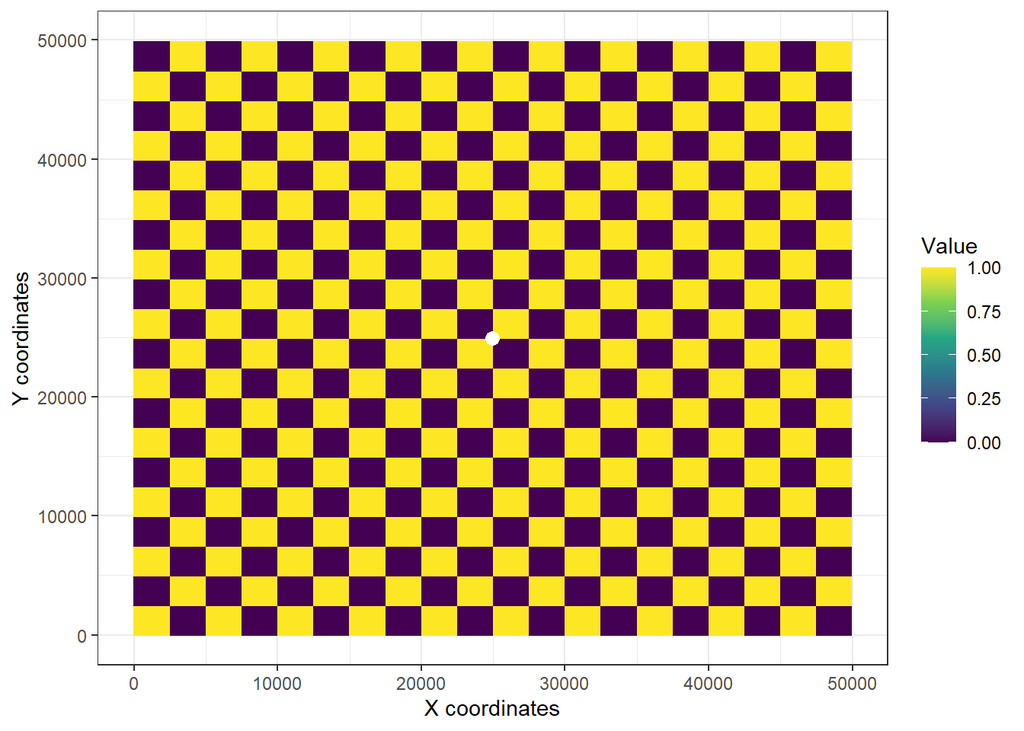

```r
centre <- c(24950, 24950)
ggplot(df, aes(x = x, y = y, fill = value)) +
  geom_raster() +
  geom_point(aes(x=centre[1], y=centre[2]), col="white",size=3)+
  labs(fill = "Value") +
  xlab("X coordinates")+
  ylab("Y coordinates") +
  scale_fill_viridis_c()+
  theme_bw()
```

# Movement data simulation

### Behavioural states

Following Michelot et al. (2017), each central-place foraging (CPF) movement path was represented as a sequence of four behavioural states:

1. outbound travel (fast, highly directed movement away from the central place),
2. search (moderately fast movement with some directional persistence)
3. active foraging (slower, less directed and more sinuous movement), and
4. inbound travel (fast, directed movement towards the central place).

### State transition model

Transitions between behavioural states were governed by a probabilistic matrix informed by Euclidean distance to the colony, time since departure from the nest, and habitat suitability. Transition probabilities were computed using a multinomial logit formulation, with parameters chosen to reflect biologically realistic behaviour—for example, an increased probability of switching to foraging in suitable habitat (Michelot et al. 2017).

$$T =
\begin{pmatrix}
1 - \gamma_{1,2} & \gamma_{1,2} & 0 & 0 \\
0 & 1 - \gamma_{2,3} - \gamma_{2,4} & \gamma_{2,3} &
\gamma_{2,4} \\
0 & 0 & 1 - \gamma_{3,4} & \gamma_{3,4} \\
0 & 0 & 0 & 1
\end{pmatrix}$$

where $\gamma_{A, B}$ represents the probability of switching from behavioural state A to behavioural state B and behaviours are numbered according to their canonical progression during a single foraging trip (i.e., outbound (1) $\rightarrow$ search (2) $\rightarrow$ foraging (3) $\rightarrow$ (4) inbound). Each row and column in $T$ corresponds to a separate behaviour: values along the diagonal give the probabilities of remaining in the same state, whereas off-diagonal values denote probabilities of switching from the row state to the column state. For instance, $\gamma_{1,2}$ corresponds to the probability of transitioning from outbound travel to search.

We defined:

$$\gamma_{2,4} = e^{\eta_{2,4}} /
D$$

$$\gamma_{3,4} =
\operatorname{logit}^{-1}(\eta_{3,4})$$

with $D = 1 + e^{\eta_{2,3}} + e^{\eta_{2,4}}$.

The linear predictors were specified as:

- $\eta_{1,2}= -3 + 0.0005 \times \text{distance to colony} + 1.5 \times \text{habitat}$
- $\eta_{2,3}= -5 + 3 \times \text{habitat}$
- $\eta_{2,4}= -6 + 0.05 \times \text{time since departure}$
- $\eta_{3,4}= -5 + 0.015 \times \text{time since departure}$

```r
addLogit_rcpp <- function(x1, x2) {
  p1 <- exp(x1)
  p2 <- exp(x2)
  res <- c(p1 / (1 + p1 + p2), p2 / (1 + p1 + p2), 1 - (p1 / (1 + p1 + p2)) - (p2 / (1 + p1 + p2)))
  return(res)
}

trMatrix_rcpp <- function(beta, dist, time, cov) {

  trMat <- matrix(ncol=4, nrow=4)

  trMat[1, 1] <- 1 - plogis(beta[1] + beta[2] * dist + beta[3] * cov) # prob of staying in stage 1
  trMat[1, 2] <- plogis(beta[1] + beta[2] * dist + beta[3] * cov)# prob of going from stage 1 to 2 as a function of cov
  trMat[1, 3] <- 0 # prob of going from stage 1 to 3
  trMat[1, 4] <- 0 # prob of going from stage 1 to 4

  foo23 <- beta[4] + beta[5] * cov # prob of going from stage 2 to 3 as a function of cov
  foo24 <- beta[6] + beta[7] * time # prob of going from stage 2 to 4 as a function of time

  r2 <- addLogit_rcpp(foo23, foo24)

  trMat[2, 1] <- 0 # prob of going from stage 2 to 1
  trMat[2, 2] <- r2[3] # prob of staying stage 2
  trMat[2, 3] <- r2[1] # prob of going from stage 2 to 3
  trMat[2, 4] <- r2[2] # prob of going from stage 2 to 4

  trMat[3, 1] <- 0 # prob of going from stage 3 to 1
  trMat[3, 2] <- 0 # prob of going from stage 3 to 2
  trMat[3, 3] <- 1 - plogis(beta[8] + beta[9] * time) # prob of staying in stage 3
  trMat[3, 4] <- plogis(beta[8] + beta[9] * time) # prob of going from stage 3 to 4 as a function of time

  trMat[4, 1] <- 0 #prob of staying in stage 4
  trMat[4, 2] <- 0 #prob of staying in stage 4
  trMat[4, 3] <- 0 #prob of staying in stage 4
  trMat[4, 4] <- 1 #prob of staying in stage 4

  return(trMat)
}

#linear predictors
beta <- c(-3, 0.0005, 1.5,   # stage 1 → 2
          -5, 3,              # stage 2 → 3
          -6, 0.05,           # stage 2 → 4
          -5, 0.015)          # stage 3 → 4

#Number of states
nbStates<-4
```

### State-specific parameters

Directional travel (outbound and inbound) was modelled as a biased correlated random walk, incorporating repulsion from the colony during outbound movement and attraction towards the colony during inbound movement. In contrast, search and foraging behaviours were modelled as correlated random walks. Step lengths and turning angles were modelled using gamma and von Mises distributions, respectively, with state-specific parameter values.

| Behavioural state (No.) | μ | σ | θ | κ |
| --- | --- | --- | --- | --- |
| Outbound (1) | 571.8 | 195.4 | $\alpha_t + \pi$ | 14 |
| Search (2) | 350.0 | 190.0 | 0 | 5 |
| Foraging (3) | 108.0 | 131.2 | $\pi$ | 0.84 |
| Inbound (4) | 571.8 | 195.4 | $\alpha_t$ | 14 |

```r
#choose model parameters
mu <- c(571.8,350, 108, 571.8) # step mean - in meters for 1 min interval (original values for kittiwakes in 5 min)
sigma <- c(195.4, 190 ,131.2, 195.4) # step SD
am <- c(-0.00647766,3.14001249)
kappa <- c(14, 5, 0.84, 14) # angle concentration - (Larger values lead to lower variance of the von Mises distribution, and hence higher persistence in direction.)
```

### Step selection

At each time step, we drew 10,000 candidate steps from the movement kernel associated with the current behavioural state. We calculated a relative selection weight for each candidate by exponentiating the linear predictor and then selected one end point probabilistically as the animal’s next location. Each candidate step $i$ was evaluated using a log‑linear model of the form:

$$\log(w_i) = \beta_1 \times L_i + \beta_2 \times \log L_i + \beta_3
\times h_i$$

$$w_i = \exp(\eta_i) \quad \mathrm{Pr}(i) = \frac{\exp(\eta_i)}{\sum_j
\exp(\eta_j)}$$

where $L_i$ is the step length, $h_i$ is the habitat covariate and $\beta_1, \beta_2$ and $\beta_3$ are the corresponding selection coefficients.

Individuals were initialised at the colony at time $t = 0$, with the first step generated by drawing a direction $\phi_0 \sim \mathrm{von\ Mises}(0, 1)$ and a step length $L_0 \sim \mathrm{Gamma}(k, \theta)$. The latter was parameterised in terms of the state-specific mean $\mu$ and standard deviation $\sigma$ for outbound travel, such that $k = \mu^2 / \sigma^2$ and $\theta = \sigma^2 / \mu$. The resulting displacement defines the first location, and the initial turning angle was set as the direction from this location back towards the colony.

```r
### SSF parameters
# Equations exist to determine the scale and shape parameters of a gamma distribution
# based on its mean and sd
gamma_shape <- mu^2 / sigma^2
gamma_scale <- sigma^2 / mu

# The equation presented in Appendix A gives the relationship between the
# gamma distribution parameters and the selection coefficients (referred to as β1 and β2 for L and log(L) respectively).
# β1 −1/scale and β2 = shape − 2.
beta1 <- -1 / gamma_scale
beta2 <- gamma_shape - 2

cov_beta <- 1 #0.5, 0.75, 1, 1.25, 1.5, 1.75,2

ssf_formula <- as.formula(" ~ cov")

n_zeros <- 10000
```

### Simulate animal tracks

We simulate a full population of 1,000 individuals and generated 25 complete tracks per individual in each simulation.

```r
nbTracks<-25
nbID<-1000 #corresponds to all population

simulate_individual<- function(id,
                            nbTracks,
                            centre,
                            mu, sigma, kappa, am,
                            ssf_betas, ssf_formula,
                            beta,
                            nbStates,
                            n_zeros) {

  cov_raster <- terra::rast("cov_raster.tif")

  id_tracks <- vector("list", nbTracks)

  for (tr in seq_len(nbTracks)) {

    track_list <- vector("list", 5000)  # upper bound, trimmed later
    k <- 1

    state <- 1
    time <- 0

    phi <- CircStats::rvm(1, 0, 1)
    len <- rgamma(1, shape = gamma_shape[1], scale = gamma_scale[1])
    newLoc <- centre + c(len * cos(phi), len * sin(phi))
    angle <- atan2(centre[2] - newLoc[2], centre[1] - newLoc[1])

    track_list[[k]] <- data.frame(
      Track_id = tr, x = centre[1], y = centre[2],
      step = NA, angle = NA, bearing = NA,
      state = 1, time = 0, ID = id
    )
    k <- k + 1

    track_list[[k]] <- data.frame(
      Track_id = tr, x = newLoc[1], y = newLoc[2],
      step = len, angle = angle, bearing = phi,
      state = 1, time = 1, ID = id
    )
    k <- k + 1
    time <- 1

    while (!(state == 4 && sqrt(sum((newLoc - centre)^2)) < 1000)) {

      time <- time + 1
      phi0 <- phi

      dist <- sqrt(sum((newLoc - centre)^2))

      cov <- terra::extract( cov_raster,  matrix(newLoc, nrow = 1))[1,1]

      trMat <- trMatrix_rcpp(beta, dist, time, cov)
      state <- sample(seq_len(nbStates), 1, prob = trMat[state, ])

      if (state %in% c(1, 4)) {
        angle <- atan2(centre[2] - newLoc[2], centre[1] - newLoc[1])
        phi <- CircStats::rvm(
          n_zeros,
          mean = angle + ifelse(state == 1, pi, 0),
          k = kappa[state]
        )
      } else {
        angle <- CircStats::rvm(n_zeros, am[state - 1], kappa[state])
        phi <- phi + angle
      }

      len <- rgamma(
        n_zeros,
        shape = gamma_shape[state],
        scale = gamma_scale[state]
      )

      dx <- len * cos(phi)
      dy <- len * sin(phi)
      endpoints <- cbind(newLoc[1] + dx, newLoc[2] + dy)

      cov_vals <- terra::extract(cov_raster,endpoints)[,1]
      valid <- !is.na(cov_vals)

      if (!any(valid)) next

      endpoints <- endpoints[valid, , drop = FALSE]
      cov_vals <- cov_vals[valid]
      len      <- len[valid]
      phi      <- phi[valid]

      # SSF
      ssf_df <- data.frame(cov = cov_vals)

      mod_matrix <- model.matrix(ssf_formula, ssf_df)
      mod_matrix <- mod_matrix[, !colnames(mod_matrix) == "(Intercept)", drop = FALSE]

      linear_pred <- mod_matrix %*% ssf_betas[4, state]
      ssf_prob <- as.numeric(exp(linear_pred))
      ssf_prob <- ssf_prob / sum(ssf_prob)

      # boundary filter
      inside <- endpoints[,1] >= 100 & endpoints[,1] <= 49900 &
        endpoints[,2] >= 100 & endpoints[,2] <= 49900

      ssf_prob[!inside] <- 0
      if (sum(ssf_prob) == 0) next
      ssf_prob <- ssf_prob / sum(ssf_prob)

      chosen <- sample.int(length(ssf_prob), 1, prob = ssf_prob)

      newLoc <- endpoints[chosen, ]
      phi    <- phi[chosen]
      len    <- len[chosen]

      track_list[[k]] <- data.frame(
        Track_id = tr,
        x = newLoc[1], y = newLoc[2],
        step = len,
        angle = phi - phi0,
        bearing = phi,
        state = state,
        time = time,
        ID = id
      )
      k <- k + 1
    }

    id_tracks[[tr]] <- do.call(
      rbind,
      track_list[seq_len(k - 1)]
    )
  }

  do.call(rbind, id_tracks)
}

runtime <- system.time({

ncores <- parallel::detectCores() - 1
cl <- makeCluster(ncores)
registerDoParallel(cl)

for (c in seq_along(cov_beta)) {

  message("Running cov_beta = ", cov_beta[c])

  ## scenario-specific parameters
  cov_gamma  <- c(1, 1, 1, 1)
  cov_coefs  <- cov_beta[c] * cov_gamma

  ssf_betas <- matrix(
    c(beta1, beta2, kappa, cov_coefs),
    ncol = nbStates,
    byrow = TRUE
  )

  ## parallel over individuals
  data <- foreach(
    id = seq_len(nbID),
    .combine  = rbind,
    .packages = c("CircStats", "terra"),
    .export   = c(
      "simulate_individual",
      "trMatrix_rcpp",
      "cov_raster",
      "ssf_betas",
      "ssf_formula",
      "mu", "sigma", "kappa", "am",
      "beta",
      "centre",
      "nbTracks",
      "nbStates",
      "n_zeros")
  ) %dopar% {

    simulate_individual(
      id         = id,
      nbTracks   = nbTracks,
      centre     = centre,
      mu         = mu,
      sigma      = sigma,
      kappa      = kappa,
      am         = am,
      ssf_betas  = ssf_betas,
      ssf_formula = ssf_formula,
      beta       = beta,
      nbStates   = nbStates,
      n_zeros    = n_zeros
    )
  }

  ## save per-scenario
  data_sf <- sf::st_as_sf(data, coords = c("x", "y"), crs = 32630)

  save(
    data_sf,
    file = paste0("CPF_cov", cov_beta[c], "_", nbID, "ind.RData")
  )
}

stopCluster(cl)
})
```

```
## Running cov_beta = 1
```

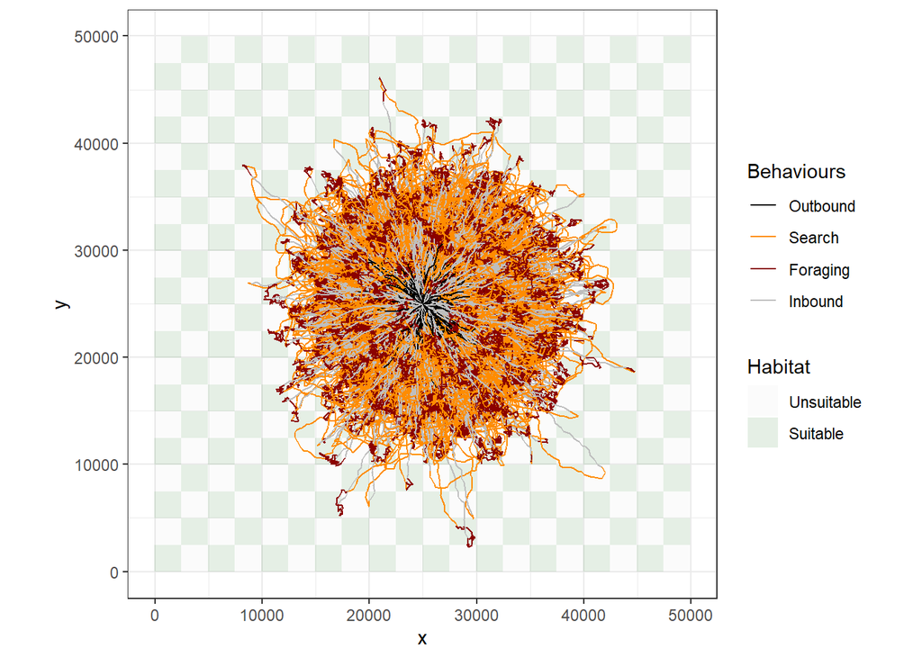

```r
# plot tracks
ggplot() +
  geom_tile(data=df, aes(x,y,fill=factor(value)), alpha=0.1)+
  geom_path(data= data, aes(x, y, col= factor(state), group = ID))+
  scale_fill_manual(values = c("lightgrey", "darkgreen"), name = "Habitat", labels=c("Unsuitable", "Suitable"))+
   scale_colour_manual(values = c("black", "darkorange", "darkred", "grey"), name = "Behaviours", labels=c("Outbound", "Search", "Foraging", "Inbound"))+
  theme_bw() +
  coord_fixed()
```

# Computational performance

Simulation time was measured using the `system.time()` function in R. A total of 1 habitat-selection scenarios were evaluated. For each scenario, 25 complete tracks were generated for each of 1,000 simulated individuals. The complete simulation required 531.53 minutes (elapsed time) and was executed in parallel using 7 CPU cores.

For reproducibility, the session information corresponding to the computational environment used for these simulations, including the R version, operating system, and package versions, is provided below.

[session information not shown]

**R version 4.6.0 (2026-04-24 ucrt)**

**Platform:** x86_64-w64-mingw32/x64

**locale:** *LC_COLLATE=English_United Kingdom.utf8*, *LC_CTYPE=English_United Kingdom.utf8*, *LC_MONETARY=English_United Kingdom.utf8*, *LC_NUMERIC=C* and *LC_TIME=English_United Kingdom.utf8*

**attached base packages:** *parallel*, *stats*, *graphics*, *grDevices*, *utils*, *datasets*, *methods* and *base*

**other attached packages:** *doParallel(v.1.0.17)*, *iterators(v.1.0.14)*, *foreach(v.1.5.2)*, *ggplot2(v.4.0.3)*, *sf(v.1.1-2)*, *terra(v.1.9-34)*, *CircStats(v.0.2-7)*, *boot(v.1.3-32)* and *MASS(v.7.3-65)*

**loaded via a namespace (and not attached):** *sass(v.0.4.10)*, *generics(v.0.1.4)*, *class(v.7.3-23)*, *KernSmooth(v.2.23-26)*, *digest(v.0.6.39)*, *magrittr(v.2.0.5)*, *evaluate(v.1.0.5)*, *grid(v.4.6.0)*, *RColorBrewer(v.1.1-3)*, *fastmap(v.1.2.0)*, *jsonlite(v.2.0.0)*, *e1071(v.1.7-17)*, *DBI(v.1.3.0)*, *pander(v.0.6.6)*, *viridisLite(v.0.4.3)*, *scales(v.1.4.0)*, *codetools(v.0.2-20)*, *jquerylib(v.0.1.4)*, *cli(v.3.6.6)*, *rlang(v.1.3.0)*, *units(v.1.0-1)*, *withr(v.3.0.3)*, *cachem(v.1.1.0)*, *yaml(v.2.3.12)*, *otel(v.0.2.0)*, *tools(v.4.6.0)*, *dplyr(v.1.2.1)*, *vctrs(v.0.7.3)*, *R6(v.2.6.1)*, *proxy(v.0.4-29)*, *lifecycle(v.1.0.5)*, *classInt(v.0.4-11)*, *pkgconfig(v.2.0.3)*, *bslib(v.0.12.0)*, *pillar(v.1.11.1)*, *gtable(v.0.3.6)*, *glue(v.1.8.1)*, *Rcpp(v.1.1.2)*, *xfun(v.0.60)*, *tibble(v.3.3.1)*, *tidyselect(v.1.2.1)*, *knitr(v.1.51)*, *farver(v.2.1.2)*, *htmltools(v.0.5.9)*, *labeling(v.0.4.3)*, *rmarkdown(v.2.31)*, *compiler(v.4.6.0)* and *S7(v.0.2.2)*

# References

Avgar, Tal, Jonathan R Potts, Mark A Lewis, and Mark S Boyce. 2016. “Integrated Step Selection Analysis: Bridging the Gap Between Resource Selection and Animal Movement.” *Methods in Ecology and Evolution* 7 (5): 619–30. https://doi.org/10.1111/2041-210x.12528.

Hijmans, Robert J. 2026. *Geosphere: Spherical Trigonometry*.

Klappstein, N J, L Thomas, and T Michelot. 2023. “Flexible Hidden Markov Models for Behaviour-Dependent Habitat Selection.” *Movement Ecology* 11 (1): 30. https://doi.org/10.1186/s40462-023-00392-3.

Michelot, Théo, Roland Langrock, Sophie Bestley, Ian D Jonsen, Theoni Photopoulou, and Toby A Patterson. 2017. “Estimation and Simulation of Foraging Trips in Land-Based Marine Predators.” *Ecology* 98 (7): 1932–44. https://doi.org/10.1002/ecy.1880.